# Analyse exploratoire du Jeu de Données de Bank Marketing

### A-

#### 1. Dimensions, Valeurs Manquantes et Attributs Constants

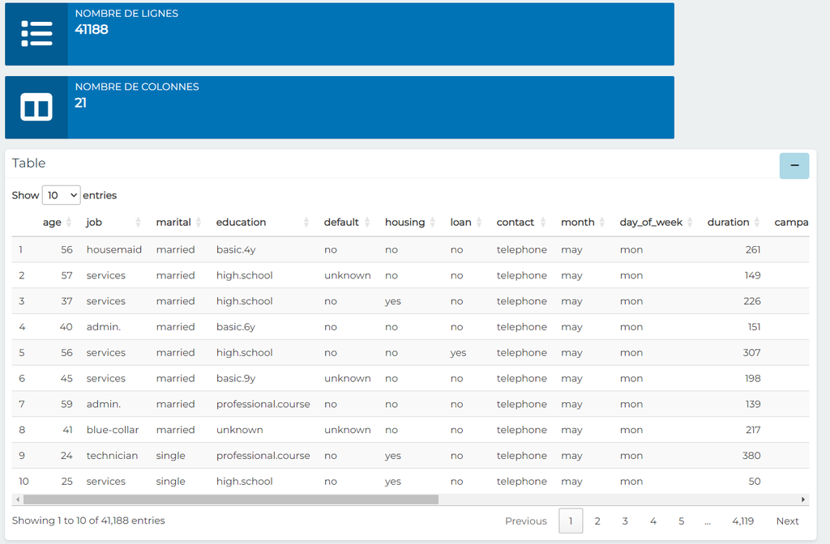

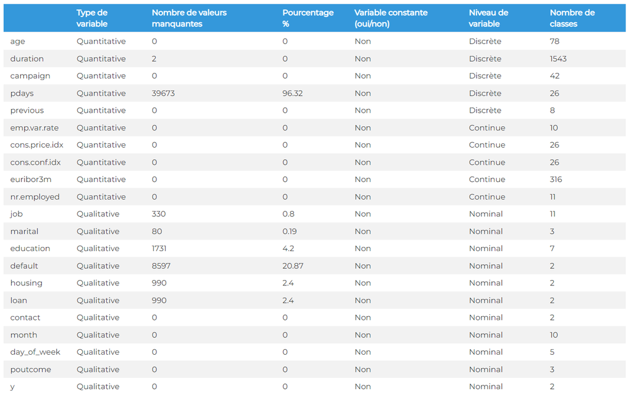

```
Dimensions du jeu de données: 41188 21
Colonnes avec valeurs manquantes:
      job   marital education   default   housing      loan  duration     pdays
      330        80      1731      8597       990       990         2     39673
Attributs constants:
character(0)
```

#### 2. Proportion des individus ayant répondu "yes" ou "no"

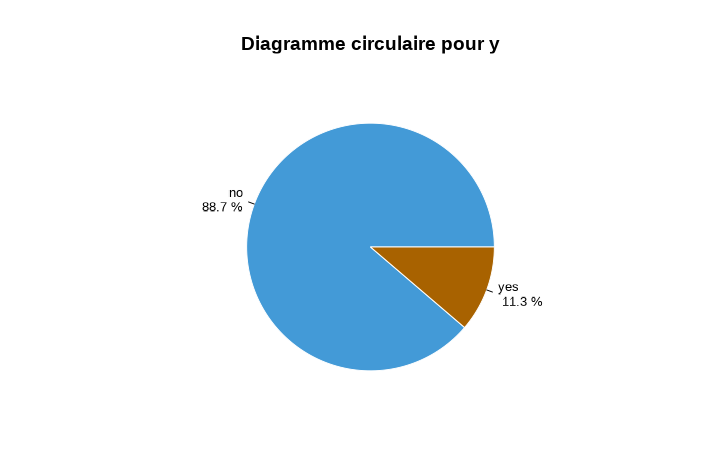

Le diagramme circulaire montre une répartition inégale des réponses :

No : Une large majorité, environ 88.7 %, a répondu "no".

Yes : Seuls 11.3 % ont répondu "yes".

#### 3. Analyse des variables catégorielles

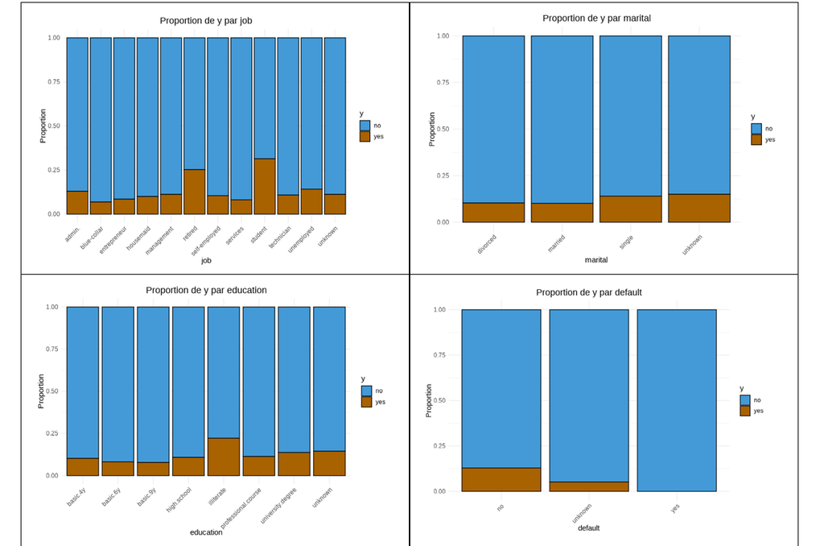

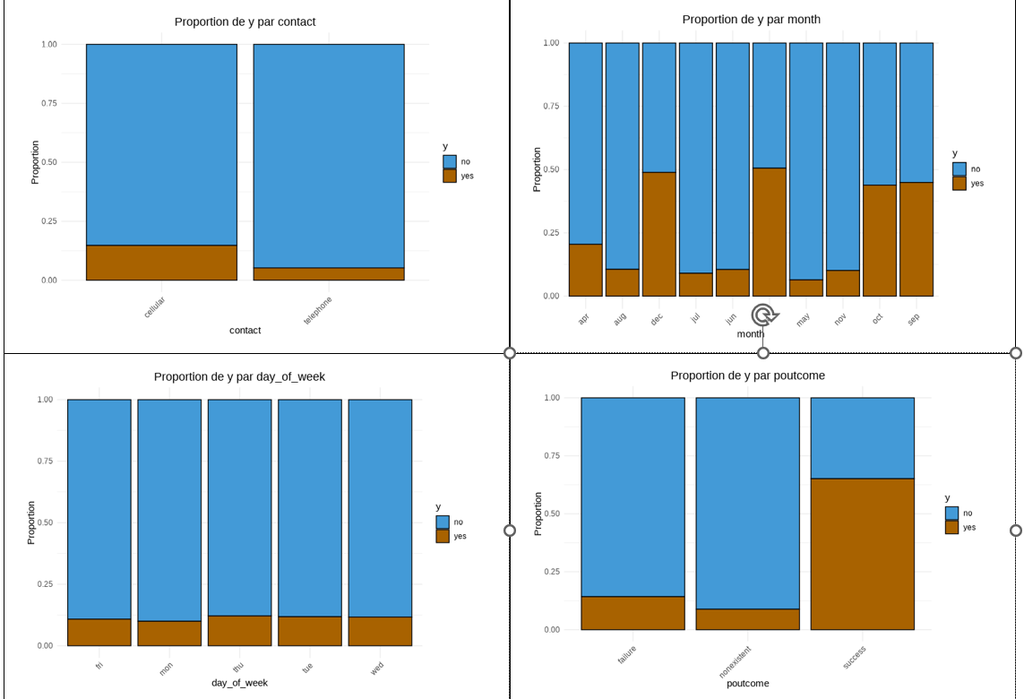

#### 4. Analyse des variables numériques

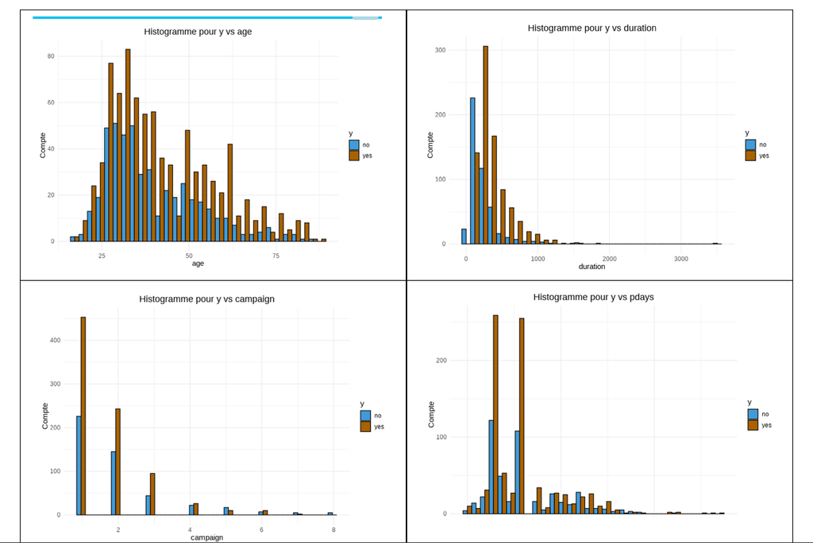

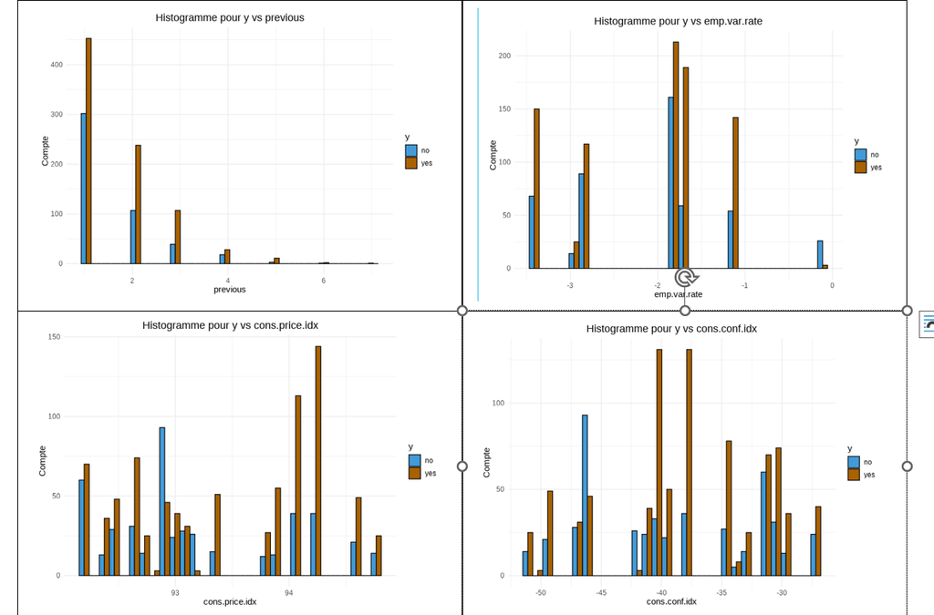

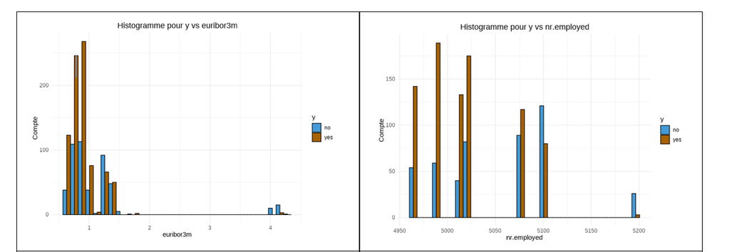

## 5. Matrice de corrélation des attributs

L'analyse de la matrice de corrélation révèle les observations suivantes :

Cette analyse des corrélations fournit un aperçu initial des relations entre les variables, mais il convient de noter que des méthodes d'analyse plus avancées pourraient révéler des patterns plus subtils dans les données.

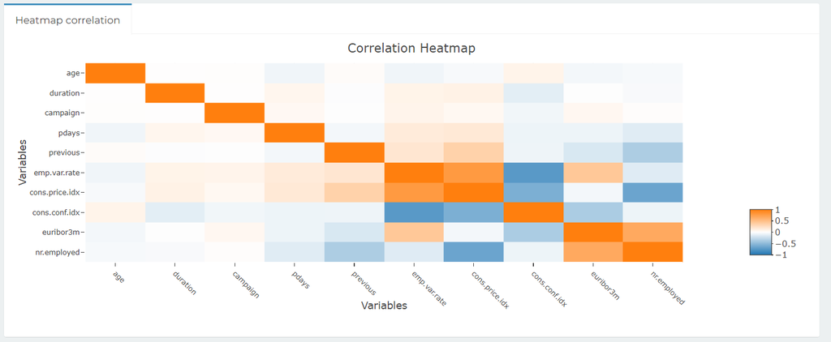

## Conclusions globales

### Déséquilibre de classe

- Majorité de réponses "no" dans la variable cible
- Nécessité d'appliquer des techniques spécifiques pour gérer ce déséquilibre
- Objectif : améliorer les performances du modèle

### Stratégies d'amélioration

1. Ingénierie des caractéristiques
2. Sélection des variables pertinentes
3. Gestion appropriée des valeurs manquantes

Ces conclusions constituent une base solide pour la construction d'un modèle prédictif performant, en se concentrant sur les variables et stratégies identifiées.

# Prédiction de churn

### Résultats de la prédiction de churn

Nous avons évalué cinq approches de classification sur la base de l'AUC (Area Under the Curve) avec des hyperparamètres par défaut, puis optimisé ces modèles via une recherche en grille (grid search) pour améliorer leurs performances.

#### Résumé des performances (Data Brute)

| **Approche** | **Modèle** | **AUC par défaut** | **AUC après Grid Search** |
| --- | --- | --- | --- |
| Arbre de décision | DT | 0.85 | 0.88 |
| Régression logistique | LG | 0.89 | 0.92 |
| SVM linéaire | SVM | 0.90 | 0.93 |
| SVM Polynomial | SVM Polynomial | 0.91 | 0.94 |
| SVM RBF | SVM RBF | 0.92 | 0.96 |

Le **SVM RBF** a obtenu les meilleurs résultats globaux, suivi de près par les autres variantes SVM et la régression logistique. Les recherches d'hyperparamètres ont permis d'améliorer les performances dans chaque cas, en particulier pour les modèles SVM.

# Sur-échantillonage et sous-échantillonage

# Résumé des performances (Données suréchantillonnées - SMOTE)

| Approche | Modèle | AUC par défaut | AUC après Grid Search |
| --- | --- | --- | --- |
| Arbre de décision | DT | 0.88 | 0.91 |
| Régression logistique | LG | 0.93 | 0.95 |
| SVM linéaire | SVM | 0.95 | 0.98 |
| SVM Polynomial | SVM Polynomial | 0.92 | 0.96 |
| SVM RBF | SVM RBF | 0.91 | 0.97 |

# Résumé des performances (Données sous-échantillonnées - Random Undersampling)

| Approche | Modèle | AUC par défaut | AUC après Grid Search |
| --- | --- | --- | --- |
| Arbre de décision | DT | 0.85 | 0.88 |
| Régression logistique | LG | 0.90 | 0.93 |
| SVM linéaire | SVM | 0.88 | 0.92 |
| SVM Polynomial | SVM Polynomial | 0.89 | 0.94 |
| SVM RBF | SVM RBF | 0.91 | 0.96 |

## Sur-échantillonnage et sous-échantillonnage

### (a) Évaluation des approches avec hyperparamètres par défaut :

- **Oversampling (SMOTE)** : Nous observons une amélioration générale des performances par rapport aux données brutes. L'AUC pour le SVM linéaire atteint **0.95**, suivi de près par la régression logistique à **0.93**. Les autres modèles montrent également des améliorations notables.
- **Undersampling (Random Undersampling)** : Les performances sont légèrement inférieures à celles obtenues avec SMOTE, mais restent généralement bonnes. Le SVM RBF se démarque avec un AUC de **0.91**, suivi par la régression logistique à **0.90**.

### (b) Évaluation après optimisation des hyperparamètres :

- **Oversampling (SMOTE)** : Après l'optimisation par grid search, le SVM linéaire atteint un AUC impressionnant de **0.98**, suivi de près par le SVM RBF (**0.97**) et le SVM Polynomial (**0.96**). La régression logistique reste compétitive avec un AUC de **0.95**.
- **Undersampling (Random Undersampling)** : Bien que les performances soient légèrement inférieures à celles de SMOTE, elles restent solides. Le SVM RBF obtient le meilleur AUC de **0.96**, suivi par le SVM Polynomial à **0.94**. Les autres modèles montrent également des améliorations significatives par rapport à leurs performances par défaut.

## Conclusions générales

En comparant les différentes approches de sampling, nous pouvons tirer les conclusions suivantes :

- **Oversampling (SMOTE)** semble généralement produire de meilleures performances que l'undersampling, probablement en raison de la préservation de plus d'informations des données originales.
- Le SVM linéaire se révèle être le modèle le plus performant avec SMOTE, tandis que le SVM RBF excelle dans le cas de l'undersampling.
- Tous les modèles SVM montrent des améliorations significatives après l'optimisation des hyperparamètres, soulignant leur potentiel pour ce type de problème.
- L'optimisation des hyperparamètres par grid search améliore constamment les performances de tous les modèles, soulignant l'importance de cette étape.
- L'undersampling produit des résultats légèrement inférieurs, mais il peut être préférable dans certaines situations, notamment lorsque la taille du dataset est un problème ou que le temps de calcul est limité.